# IEFCIC R Notebook

Éste es un [R Markdown](http://rmarkdown.rstudio.com) Notebook. Cuando ejecutes el código contenido, los resultados aparecerán debajo del código.

Los archivos que se van a usar fueron descargados de datos.gov.co. Luego fueron extraídos de forma local en formato .txt y .sav.

En el [vídeo](https://www.youtube.com/watch?v=6ULCP7NsITY) se explica paso a paso la obtención de datos

1. Cargando las librerías requeridas

```r
library(haven)
df <- read_sav("./IEFIC_2015.sav")
head(df)
```

| ANIO | CLASE | DIRECTORIO_GEIH | FEX_C | INGRESO_COMPLETO | INGTOTOB | LLAVE_PER_GEIH | ORDEN | PERIODO | SECUENCIA_P | P10 | P1136 | P1237 | P1239 | P1421 | P2168 | P2211 | P232 | P241 | P242 | P2424 | P2439 | P2447 | P2461 | P2462 | P2464 | P2465 | P2466 | P2469 | P2470 | … |
| --- | --- | --- | --- | --- | --- | --- | --- | --- | --- | --- | --- | --- | --- | --- | --- | --- | --- | --- | --- | --- | --- | --- | --- | --- | --- | --- | --- | --- | --- | --- |
| 2015 | 1 | 3641876 | 230.5553 | 1 | 1242080 | 201501364187611 | 1 | 1 | 1 | 100 | NaN | NaN | 2 | NaN | NaN | NaN | 2 | 85 | 1 |  | 1 | 1987 | 1.0e+08 | 2 | NaN | NaN | 2 | NaN | NaN | … |
| 2015 | 1 | 3641876 | 230.5553 | 1 | 975000 | 201501364187612 | 2 | 1 | 1 | 511 | 3e+06 | NaN | 2 | NaN | NaN | NaN | 2 | 55 | 3 |  | 1 | 1987 | 1.0e+08 | 2 | NaN | NaN | 2 | NaN | NaN | … |
| 2015 | 1 | 3641879 | 255.8069 | 1 | 792080 | 201501364187911 | 1 | 1 | 1 | 409 | NaN | NaN | 2 | NaN | NaN | NaN | 3 | 68 | 1 |  | 1 | 1982 | 5.0e+07 | 2 | NaN | NaN | 2 | NaN | NaN | … |
| 2015 | 1 | 3641879 | 255.8069 | 1 | 700000 | 201501364187912 | 2 | 1 | 1 | 602 | NaN | NaN | NaN | NaN | NaN | NaN | 3 | 27 | 3 |  | 1 | 1982 | 5.0e+07 | 2 | NaN | NaN | 2 | NaN | NaN | … |
| 2015 | 1 | 3641879 | 255.8069 | 1 | 1958867 | 201501364187913 | 3 | 1 | 1 | 602 | NaN | NaN | 2 | NaN | NaN | NaN | 3 | 33 | 3 |  | 1 | 1982 | 5.0e+07 | 2 | NaN | NaN | 2 | NaN | NaN | … |
| 2015 | 1 | 3641880 | 201.7251 | 1 | 1600000 | 201501364188011 | 1 | 1 | 1 | 409 | NaN | 9 | 1 | 9 | NaN | NaN | 3 | 63 | 1 |  | 1 | 1981 | 4.5e+07 | 2 | NaN | NaN | 2 | NaN | NaN | … |

2. Preparando el set de datos: tratando los NAs, tipo de estructura de datos.

```r
df[df == "NaN"] <- "NA" ## Convertir todos los NaN a NA
library(data.table) ## Libreria requerida
dt <- data.table(df) # pasando del formato data frame a data table
```

3. Extrayendo un subgrupo de variables: Nos vamos a quedar solamente con las que tiene que ver con productos financieros. Creamos una variable “dfinanc” que conserve las variables de la 195 a la 201, que en el vídeo se explica a que corresponden.

```r
dfinanc <- dt[, c(195:201), with = FALSE] ## seleccionando lo que tiene que ver con productos financieros
dfinanc <- sapply(dfinanc, FUN = function(x) {x <- as.numeric(x)}) ## pasando character a numeric
```

[output not shown]

```r
dfinanc <- as.data.table(dfinanc) ## convirtiendo de tipo matrix a datatable
summary(dfinanc) ## estadísticas básicas de las variables
```

```
     P2966              P2967           P2968               P2969              P2970
 Min.   :       0   Min.   :1.000   Min.   :0.000e+00   Min.   :       0   Min.   :1.000
 1st Qu.:       8   1st Qu.:2.000   1st Qu.:1.000e+06   1st Qu.:       8   1st Qu.:2.000
 Median :       8   Median :2.000   Median :1.000e+07   Median :       8   Median :2.000
 Mean   :  271767   Mean   :1.992   Mean   :6.929e+07   Mean   :  261978   Mean   :2.005
 3rd Qu.:      98   3rd Qu.:2.000   3rd Qu.:3.625e+07   3rd Qu.:      98   3rd Qu.:2.000
 Max.   :15000000   Max.   :9.000   Max.   :4.000e+09   Max.   :24000000   Max.   :9.000
 NA's   :18425      NA's   :709     NA's   :18372       NA's   :18300      NA's   :709
     P2971               P2972
 Min.   :        0   Min.   :       0
 1st Qu.:   100000   1st Qu.:       0
 Median :  3000000   Median :       8
 Mean   : 18346155   Mean   : 4168208
 3rd Qu.: 12500000   3rd Qu.:  525000
 Max.   :300000000   Max.   :90000000
 NA's   :18585       NA's   :18585
```

4. Entrando en el detalle de una de las variables mostradas en el resumen:

4.1. Cuántos no perciben ingresos por el instrumento financiero o no tienen

```r
nrow(dfinanc[is.na(P2966)])
```

```
[1] 18425
```

4.2. Cuantos perciben algo por el instrumento financiero o lo tienen

```r
nrow(dfinanc[!is.na(P2966)])
```

```
[1] 199
```

```r
nrow(dfinanc[!is.na(P2966)]) / nrow(dfinanc[is.na(P2966)])
```

```
[1] 0.01080054
```

5. Visualización de los datos: El analisis de los datos puede agilizarse gracias a la visualización de los mismos. Para ellos vamos a basarnos en ggplot2, una libreria de R CRAN y tendremos que hacer algunos arreglos de forma.

```r
library(ggplot2) ## cargamos la libreria de graficos
dfinanc2 <- dfinanc ## haciendo copia de los datos
dfinanc2[is.na(dfinanc2)] <- 0 ## convirtiendo a cero todos los NAs, para visualizacion
```

Para poder la gráfica de la variable que muestra ingresos por productos financieros

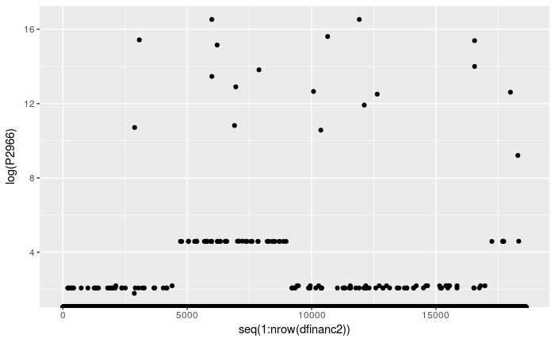

```r
ggplot(data = dfinanc2, aes(x = seq(1:nrow(dfinanc2)), y = log(P2966))) + geom_point()
```

Y veamos ahora el gráfico de la distribución de esta variable

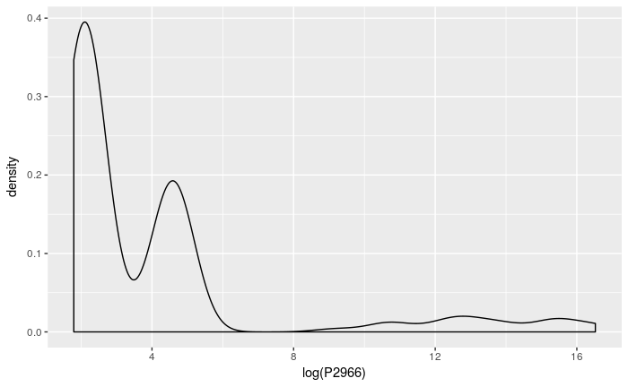

```r
ggplot(data = dfinanc2, aes(x = log(P2966))) + geom_density()
```

6. Analisis de correlaciones: “En probabilidad y estadística, la correlación indica la fuerza y la dirección de una relación lineal y proporcionalidad entre dos variables estadísticas. Se considera que dos variables cuantitativas están correlacionadas cuando los valores de una de ellas varían sistemáticamente con respecto a los valores homónimos de la otra: si tenemos dos variables (A y B) existe correlación disminuir los valores de A lo hacen también los de B y viceversa. La correlación entre dos variables no implica, por sí misma, ninguna relación de causalidad” ver ([Wikipedia](https://es.wikipedia.org/wiki/Correlaci%C3%B3n)) La última parte sobre la no causalidad es muy muy importante.

6.1. Lo primero es graficar cada variable contra las demás para apreciar en cada cuadro las correlaciones

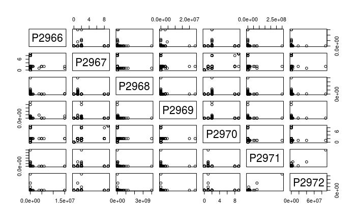

```r
pairs(dfinanc2)
```

6.2. Esto mismo podemos verlo en números, donde los valores cercanos al 1.0 indican una correlación positiva (cuando los valores de una variable aumenta los de la otra también) y los cercanos a -1.0 indican una correlación negativa (cuando los valores de una variable aumentan los de la otra disminuyen -y viceversa-)

```r
cor(dfinanc2)
```

```
              P2966         P2967        P2968         P2969        P2970         P2971
P2966  1.0000000000 -0.0100789178  0.014856870  0.0806952193  0.002710648 -0.0002659983
P2967 -0.0100789178  1.0000000000 -0.056558715 -0.0004369336  0.855897624 -0.0018933276
P2968  0.0148568700 -0.0565587147  1.000000000  0.0030866516  0.004030392  0.0027446459
P2969  0.0806952193 -0.0004369336  0.003086652  1.0000000000  0.003045413 -0.0002934361
P2970  0.0027106480  0.8558976239  0.004030392  0.0030454127  1.000000000 -0.0331238656
P2971 -0.0002659983 -0.0018933276  0.002744646 -0.0002934361 -0.033123866  1.0000000000
P2972 -0.0002003621 -0.0049559881  0.004846268 -0.0002198203 -0.024950421  0.9215707046
              P2972
P2966 -0.0002003621
P2967 -0.0049559881
P2968  0.0048462679
P2969 -0.0002198203
P2970 -0.0249504207
P2971  0.9215707046
P2972  1.0000000000
```

6.3. Hagámoslo más amable con la librería corrplot:

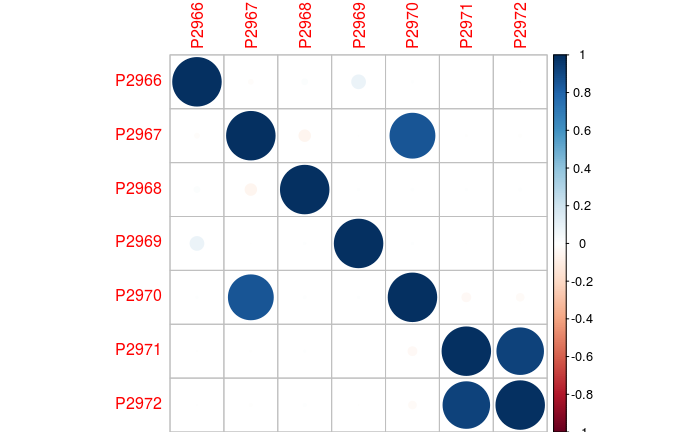

```r
library(corrplot)
corrplot(cor(dfinanc2))
```

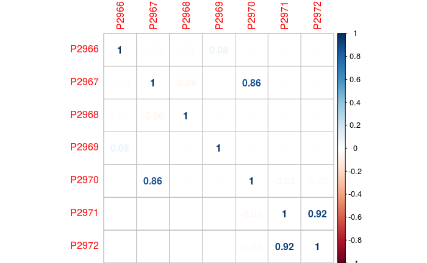

```r
corrplot(cor(dfinanc2), method = "number")
```

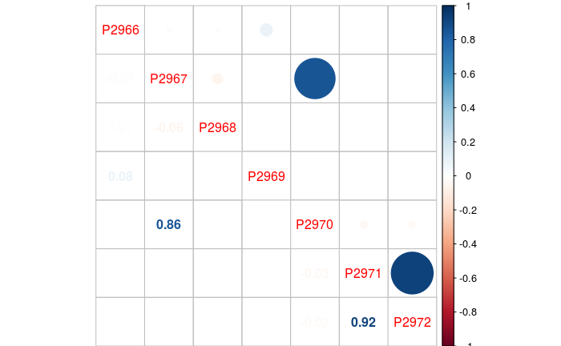

```r
corrplot.mixed(cor(dfinanc2), lower="number", upper="circle")
```

7. Finalmente, revisemos en detalle las correlaciones señaladas:

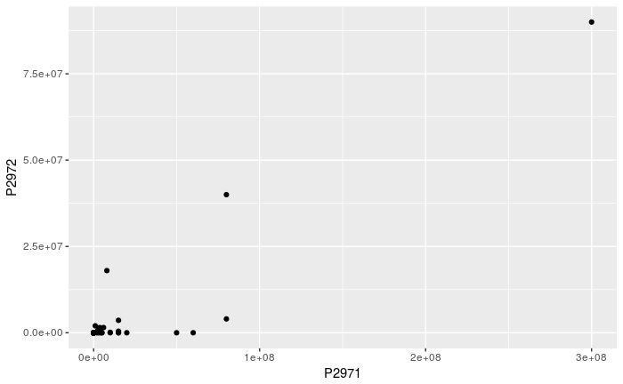

```r
ggplot(data = dfinanc2, aes(x = P2971, y = P2972)) + geom_point()
```

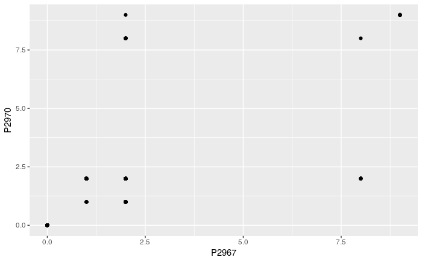

```r
ggplot(data = dfinanc2, aes(x = P2967, y = P2970)) + geom_point()
```